# Proyecto Final en R - Luis Gutiérrez

**Descripción** La sepsis ocasiona en el mundo más de mil muertes cada día, muchos de estos pacientes adquieren la infección estando hospitalizados y constituye la complicación intrahospitalaria más frecuente. La infección de pacientes por las manos contaminadas del personal de salud es una de las formas de diseminación de los agentes infecciosos. La higiene de las manos es el factor individual más importante para el control de las infecciones, es dificil entender que un hecho tan rutinario en la práctica de la medicina, como lavarse las manos previo a examinar a un paciente, haya causado tanta controversia en la época de 1800.

A principios de la década de 1840 se descubrió una enfermedad mortal que afectaba a las mujeres que acababan de dar a luz, cerca del 10% de las mujeres morían a causa de esta enfermedad y de origen provenía de las manos contaminadas del personal médico que atendía los partos.

En este proyecto, vamos a analizar los datos que demuestran la importancia del lavado de manos, identificando anomalías en los procedimientos médicos.

**Conociendo los datos**

1. Cargar el paquete tidyverse, leer el archivo “deaths_handwashing”, asignar a yearly y leerlo

| year | births | deaths | clinic |
| --- | --- | --- | --- |
| 1841 | 3036 | 237 | clinic 1 |
| 1842 | 3287 | 518 | clinic 1 |
| 1843 | 3060 | 274 | clinic 1 |
| 1844 | 3157 | 260 | clinic 1 |
| 1845 | 3492 | 241 | clinic 1 |
| 1846 | 4010 | 459 | clinic 1 |
| 1841 | 2442 | 86 | clinic 2 |
| 1842 | 2659 | 202 | clinic 2 |
| 1843 | 2739 | 164 | clinic 2 |
| 1844 | 2956 | 68 | clinic 2 |

[output cut: 2 more lines]

**El alarmante nñumero de muertes**

2. Usar mutate para agregar la columna proportion_deaths a yearly, esta nueva columna se calculará como la proporción de muertes por número de nacimientos.

| year | births | deaths | clinic | proportion_deaths |
| --- | --- | --- | --- | --- |
| 1841 | 3036 | 237 | clinic 1 | 0.07806324 |
| 1842 | 3287 | 518 | clinic 1 | 0.15759051 |
| 1843 | 3060 | 274 | clinic 1 | 0.08954248 |
| 1844 | 3157 | 260 | clinic 1 | 0.08235667 |
| 1845 | 3492 | 241 | clinic 1 | 0.06901489 |
| 1846 | 4010 | 459 | clinic 1 | 0.11446384 |
| 1841 | 2442 | 86 | clinic 2 | 0.03521704 |
| 1842 | 2659 | 202 | clinic 2 | 0.07596841 |
| 1843 | 2739 | 164 | clinic 2 | 0.05987587 |
| 1844 | 2956 | 68 | clinic 2 | 0.02300406 |

[output cut: 2 more lines]

**Muerte en las clínicas**

3. Utilizar ggplot para hacer una gráfica lineal de proportion_deaths por año (columna year) con una linea po clínica. Las líneas deben tener colores distintos.

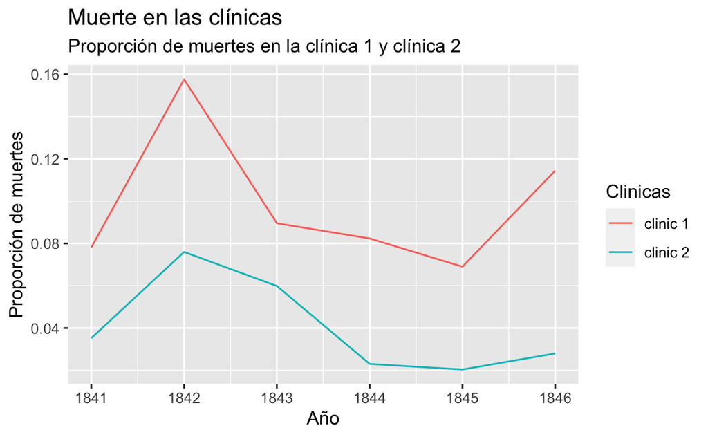

**Comienza el lavado de manos**

4. Cargar los datos mensuales de la Clinica 1 para ver si el lavado de manos tuvo algun efecto. Agregar la columna proportion_deaths a monthly, esta columna será la proporción de muertes por nacimientos.

| date | births | deaths | proportion_deaths |
| --- | --- | --- | --- |
| 1841-01-01 | 254 | 37 | 0.145669291 |
| 1841-02-01 | 239 | 18 | 0.075313808 |
| 1841-03-01 | 277 | 12 | 0.043321300 |
| 1841-04-01 | 255 | 4 | 0.015686275 |
| 1841-05-01 | 255 | 2 | 0.007843137 |
| 1841-06-01 | 200 | 10 | 0.050000000 |

**El efecto del lavado de manos**

5. Hacer una gráfica lineal de proportion_deaths por fecha para el data frame monthly usando ggplot

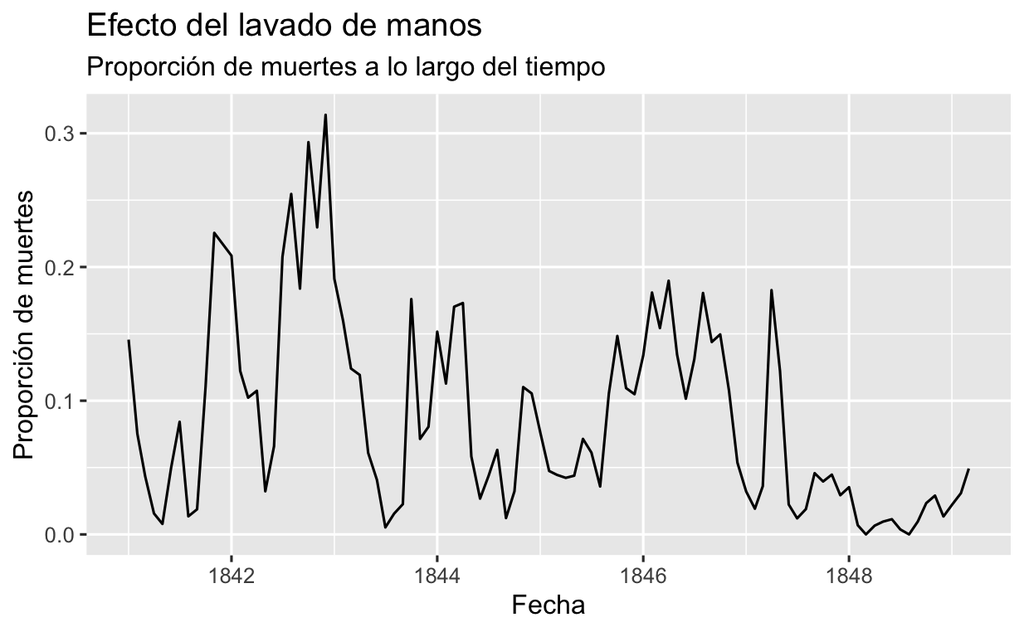

**Los Resultados del lavado de manos**

6.1. Agregar una columna T/F a monthly llamada handwashing_started, que será TRUE a partir del año en que se impueso el lavado de manos.

| date | births | deaths | proportion_deaths | handwashing_started |
| --- | --- | --- | --- | --- |
| 1841-01-01 | 254 | 37 | 0.145669291 | FALSE |
| 1841-02-01 | 239 | 18 | 0.075313808 | FALSE |
| 1841-03-01 | 277 | 12 | 0.043321300 | FALSE |
| 1841-04-01 | 255 | 4 | 0.015686275 | FALSE |
| 1841-05-01 | 255 | 2 | 0.007843137 | FALSE |
| 1841-06-01 | 200 | 10 | 0.050000000 | FALSE |
| 1841-07-01 | 190 | 16 | 0.084210526 | FALSE |
| 1841-08-01 | 222 | 3 | 0.013513514 | FALSE |
| 1841-09-01 | 213 | 4 | 0.018779343 | FALSE |
| 1841-10-01 | 236 | 26 | 0.110169492 | FALSE |

[output cut: 88 more lines]

6.2. Gráfica lineal de proportion_deaths por fecha para el data frame monthly

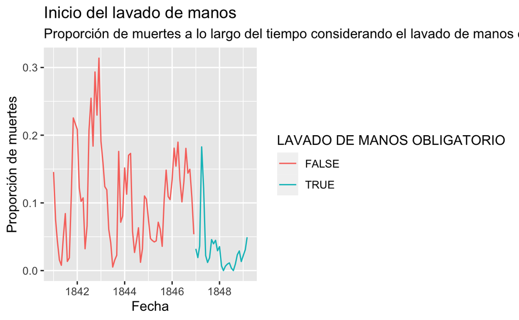

**¿Más lavado de manos, menos muertes?**

7.1. Utilizar group_by y summarise para calcular el promedio de proportion_deaths antes y despues de que se impusiera el lavado de manos.

| handwashing_started | mean_proportion_deaths |
| --- | --- |
| FALSE | 0.10691840 |
| TRUE | 0.03172764 |

**¿Cuánto redujo la proporción mensual de muertes promedio?**

Respuesta: La sepsis es una trágica respuesta a los agentes infecciosos que penetran el sistema del cuerpo humano, puede ser mortal y frecuentemente se relaciona en la hospitalización debido a la falta de cuidados de higiene del personal de salud. En este proyecto se trato de esclarecer paso a paso en cuanto redujo la proporción de muertes por nacimientos, para ello se empleo una análisis de datos con R y se concluyó según los datos mensuales, que el promedio de proporción de muertes a causa de la sepsis se redujo en un 0.07 despues que se impuso el lavado de manos obligatorio.